# Cluster Analysis and Association Rules: Exploring Sediment Chemistry and Library Transactions

Nazgul Altynbekova

```r
library(tidyverse)
library(GGally)
library(factoextra)
library(arules)
library(arulesViz)
library(ggplot2)
library(dplyr)
library(recipes)
```

### 1: Cluster Analysis

This is analysis of 38 samples of sediment collected from around the ‘Ekofisk’ oil field in the North Sea. There are seven variables representing the physical chemistry of the sediment samples. We are going to use cluster analysis to look for ‘natural’ groups of samples.

The seven variables are as follows:

| **Name** | **Description** |
| --- | --- |
| `Redox` | Oxidisation potential. |
| `Phi_mean` | Average particle size (high = sandy; low = muddy). |
| `Ba` | Concentration of barium. |
| `Sr` | Concentration of strontium. |
| `Cu` | Concentration of copper. |
| `Pb` | Concentration of lead. |
| `Ni` | Concentration of nickel. |

```r
chem <- read_csv("sediment_chemistry.csv",show_col_types = FALSE)
```

#### Initial exploration of the dataset

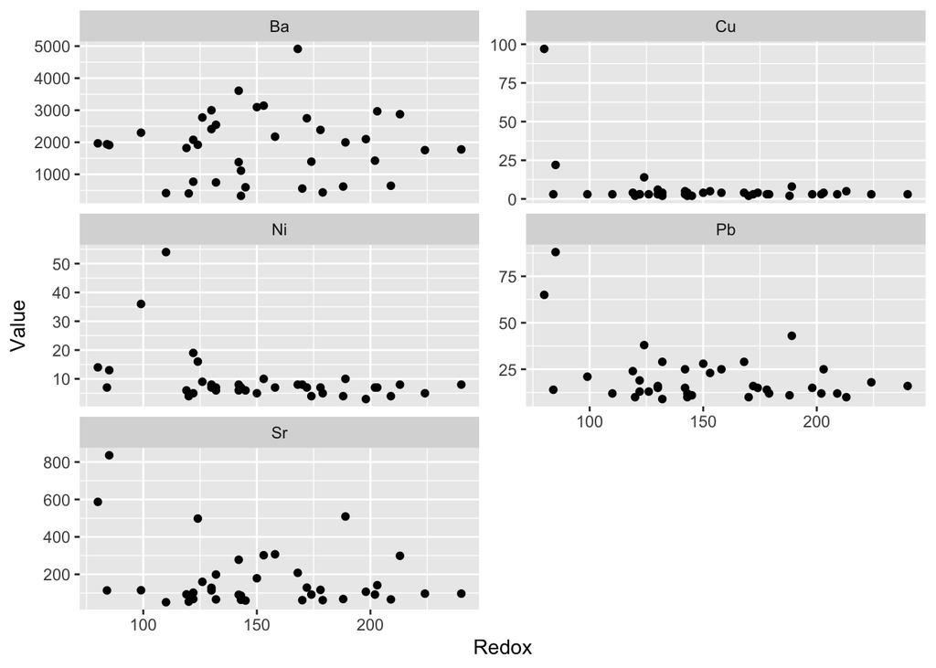

```r
chem_long <- chem |>
  rowid_to_column(var = 'id') |>
  pivot_longer(cols = -c(Redox, Phi_mean, id),
               names_to = "Name",
               values_to = "Value")

chem_long |>
  ggplot() +
  geom_point(mapping = aes(x = Redox, y = Value)) +
  facet_wrap(vars(Name), ncol = 2, scales = "free_y")
```

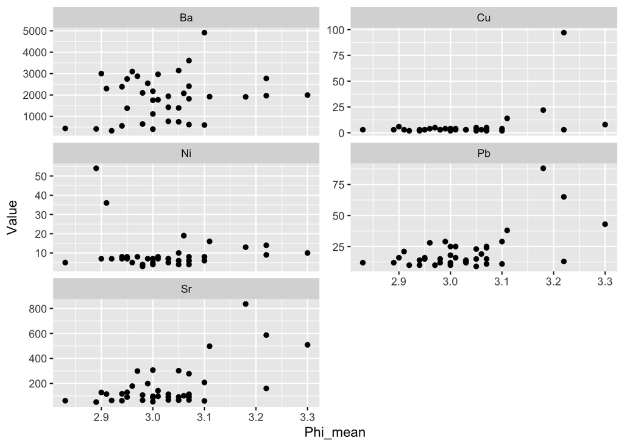

```r
chem_long |>
  ggplot() +
  geom_point(mapping = aes(x = Phi_mean, y = Value)) +
  facet_wrap(vars(Name), ncol = 2, scales = "free_y")
```

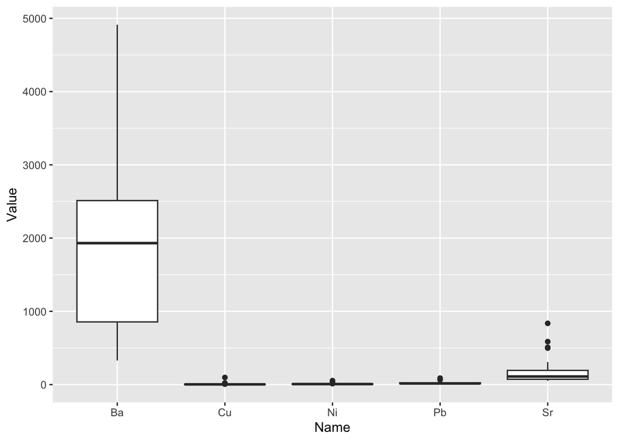

```r
chem_long |>
  ggplot() +
  aes(x = Name, y = Value) +
  geom_boxplot()
```

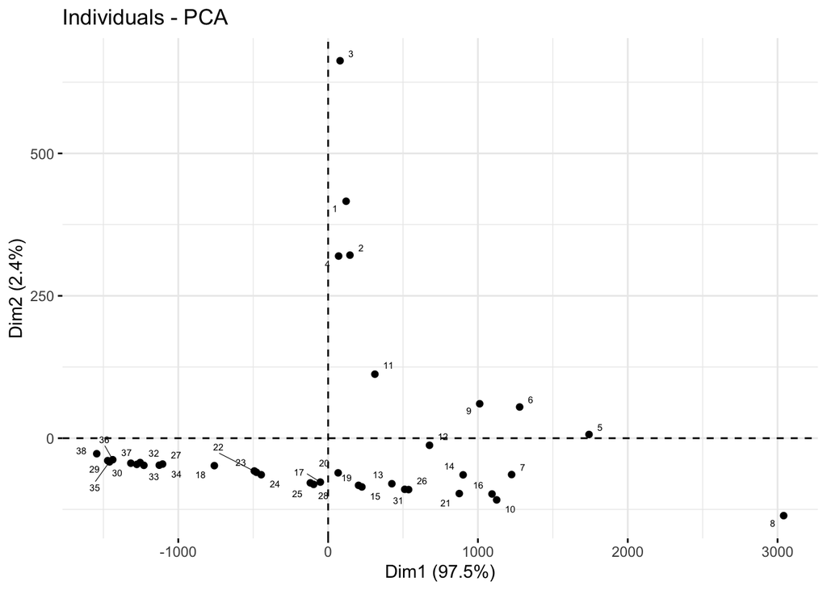

```r
chem |>
  prcomp() |>
  fviz_pca_ind(repel=T, labelsize=2)
```

As seen on a boxplot graph, the distribution of five heavy metals is rather disproportional and definitely needs scaling later. The values of Ba go from around 300 to nearly 5000, while Sr mainly gathered under 250, and the rest are lay closer to zero.

Comparing those metals with Oxidisation potential (Redox), we again observe quite a scatter from Ba with no obvious trend or pattern, Sr hints a bit on a decreasing trend, and the rest show a noticable peak on the left and rather flat distribution of the most of points.

Distribution of metals on Phi_mean shows different trends. Ba still has the most homogenous variance, but we can notice a hint of an increasing trend. This time, Sr, Cu and Pb are tend be grouped together, as they demonstrate similar image, where distribution looks rather indifferent up to the point of 3.1, after which values go much higher and further scattered. Meanwhile, Ni looks the opposite of them, having a peak in the beginning and a plain distribution on the rest of the plot.

PCA plot caught some possible patterns of grouping points, which we might confirm later in the analysis.

#### Preparing a new version of the dataset

```r
chem_norm <- chem |>
  recipe(~ .) |>
  step_log(c(Ba, Sr, Cu, Pb, Ni)) |>
  step_normalize(all_predictors()) |>
  prep() |>
  bake(chem)

chem_norm
```

```
## # A tibble: 38 × 7
##      Redox Phi_mean    Ba      Sr     Cu     Pb      Ni
##      <dbl>    <dbl> <dbl>   <dbl>  <dbl>  <dbl>   <dbl>
##  1 -1.82      2.03  0.357  2.09   4.41    2.47   1.05
##  2  0.911     2.86  0.379  1.89   0.982   1.68   0.463
##  3 -1.69      1.61  0.318  2.58   2.37    3.04   0.923
##  4 -0.715     0.886 0.325  1.86   1.75    1.45   1.29
##  5 -0.265     0.470 1.21   1.05   0.337   0.657 -0.434
##  6  0.0105    0.262 1.02   1.16   0.337   0.499  0.463
##  7 -0.0645   -0.673 0.997  0.439  0.0306  0.872 -0.754
##  8  0.386     0.782 1.65   0.647  0.0306  0.938  0.0711
##  9  1.51     -0.569 0.893  1.15   0.337  -1.08   0.0711
## 10 -0.565    -1.30  0.952 -0.0259 0.587  -0.189 -0.163
## # ℹ 28 more rows
```

We also noticed that our data values are distributed fairly unequally, with huge difference in means and variances. That, again, could lead to potential disproportion of our analysis, hence the normalization.

#### K-means cluster analysis of the new dataset

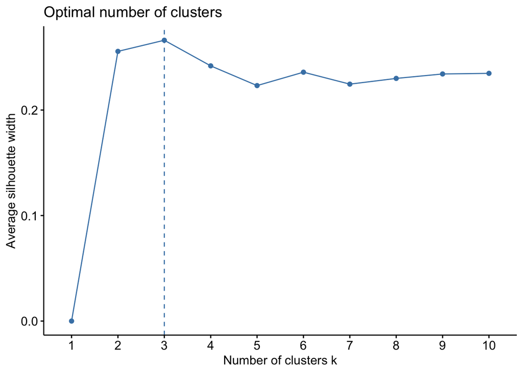

```r
chem_norm |>
  fviz_nbclust(kmeans, method = 'silhouette', k.max = 10)
```

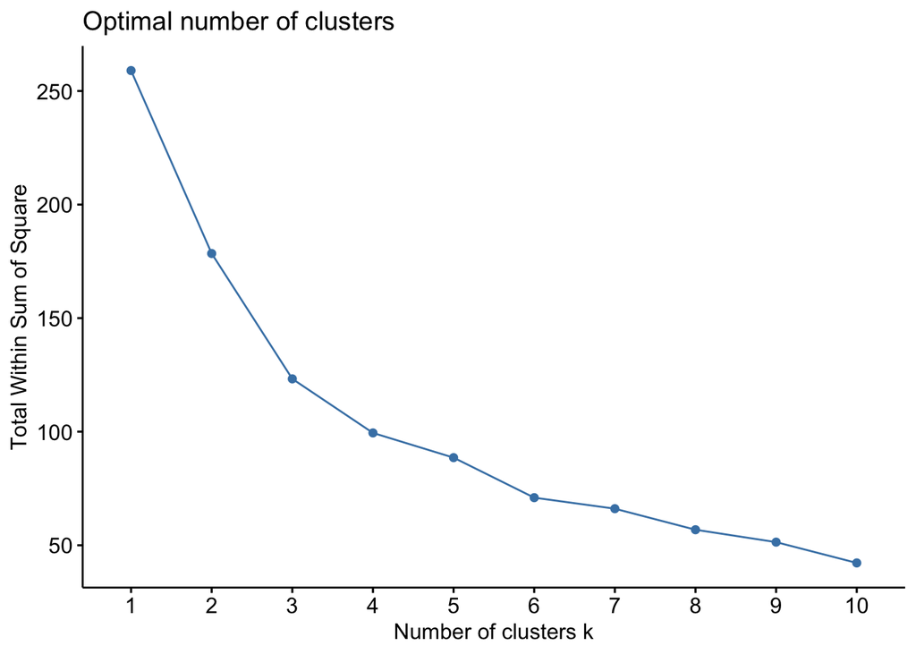

```r
chem_norm |>
  fviz_nbclust(kmeans, method = 'wss', k.max = 10)
```

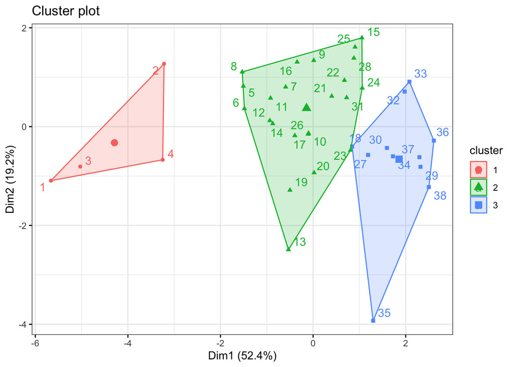

```r
set.seed(5555)
km_chem <- kmeans(chem_norm, centers = 3, nstart = 50)

km_chem |>
  fviz_cluster(data = chem_norm,
               repel = T,
               ggtheme = theme_bw())
```

To choose the appropriate value of k, the silhouette method was used. We can see that according to its graph, the optimal value for k is 3, providing the max silhouette value of ~0.27. That means that 3 clusters will give us the biggest possible distance between points of different clusters and closest possible distance between points of the same cluster.

That choice of number of k is also supported by the least sum of squares graph (wss method), where the decrease of SS becomes less rapid after k = 3.

#### Exploring the differences among the clusters

```r
chem_norm <- chem_norm |>
#  select(-Redox, -Phi_mean) |>
  add_column(Cluster = factor(km_chem$cluster))
```

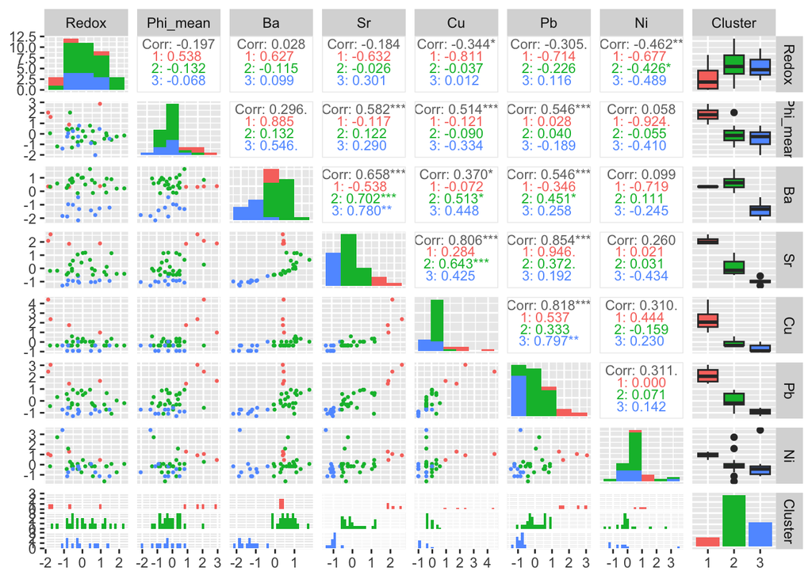

```r
chem_norm |>
  ggpairs(mapping = aes(colour = Cluster),
    upper = list(continuous = wrap("cor", size = 3)),
    lower = list(continuous = wrap("points", size = 0.5)),
    diag = list(continuous = wrap("barDiag", binwidth = 1)))
```

```r
chem_norm |>
  group_by(Cluster) |>
  summarise(across(everything(), list(mean = ~mean(.), sd = ~sd(.)), .names = "{.col}_{.fn}"))
```

```
## # A tibble: 3 × 15
##   Cluster Redox_mean Redox_sd Phi_mean_mean Phi_mean_sd Ba_mean  Ba_sd Sr_mean
##   <fct>        <dbl>    <dbl>         <dbl>       <dbl>   <dbl>  <dbl>   <dbl>
## 1 1          -0.828     1.26          1.85        0.824   0.345 0.0284   2.10
## 2 2           0.163     1.02         -0.112       0.731   0.605 0.446    0.109
## 3 3          -0.0395    0.787        -0.436       0.847  -1.39  0.495   -0.993
## # ℹ 7 more variables: Sr_sd <dbl>, Cu_mean <dbl>, Cu_sd <dbl>, Pb_mean <dbl>,
## #   Pb_sd <dbl>, Ni_mean <dbl>, Ni_sd <dbl>
```

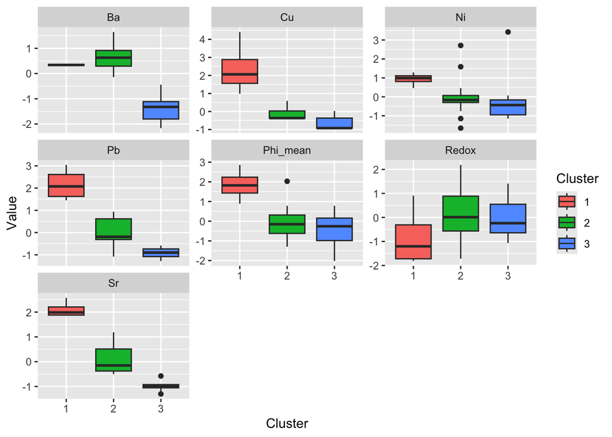

```r
chem_norm_long <- chem_norm |>
  pivot_longer(-Cluster, names_to = "Name", values_to = "Value")

ggplot(chem_norm_long, aes(x = Cluster, y = Value, fill = Cluster)) +
  geom_boxplot() +
  facet_wrap(~ Name, scales = "free_y")
```

Variables Sr and Pb seem to distinguish clusters the most, comparing on the their graphs with Redox and Phi_mean, and their own distribution of clusters.

#### Ading a new variable

```r
distoil <- read_csv("distance_to_oil_rig.csv",
                    show_col_types = FALSE)
distoil_norm <- distoil |>
  recipe(~ .) |>
  step_normalize(all_predictors()) |>
  prep() |>
  bake(distoil)
```

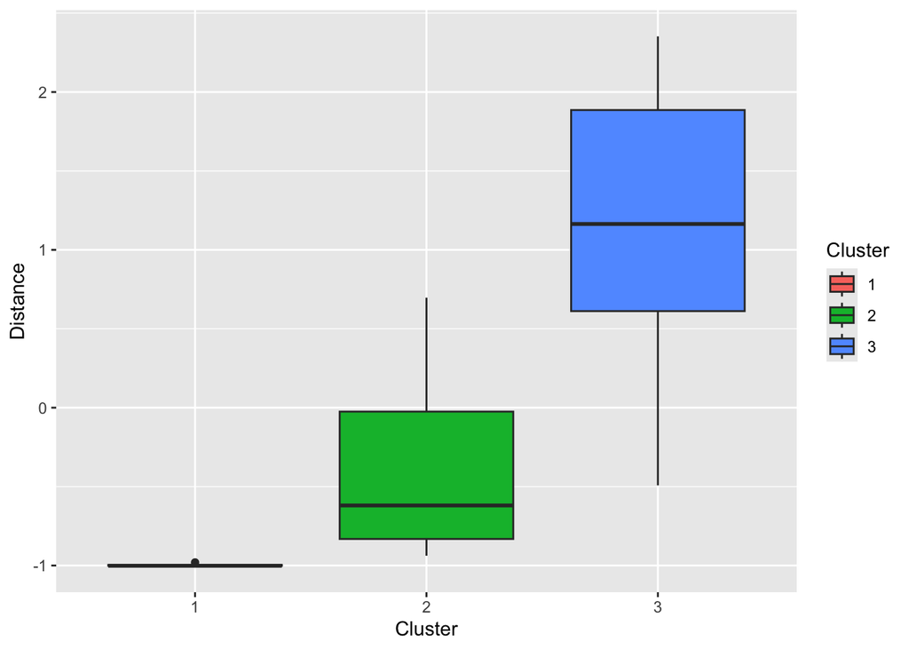

```r
chem_dist <- cbind(chem_norm, Distance = distoil_norm$Distance)

ggplot(chem_dist, aes(x = Cluster, y = Distance, fill = Cluster)) +
  geom_boxplot()
```

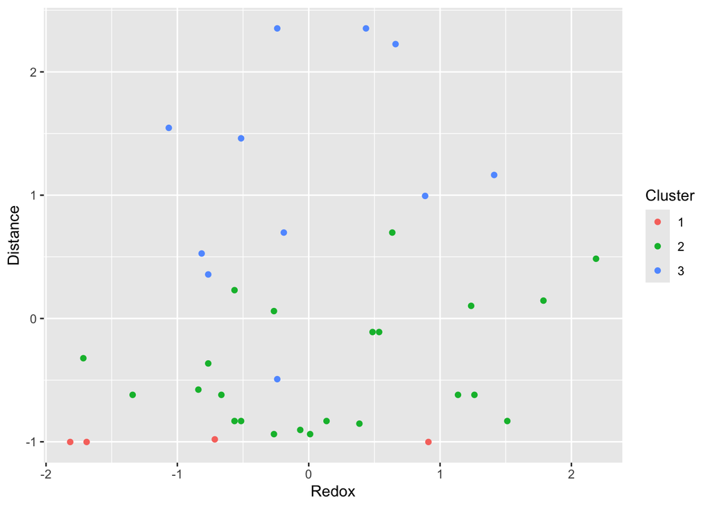

```r
ggplot(chem_dist, aes(x = Redox, y = Distance, color = Cluster)) +
  geom_point()
```

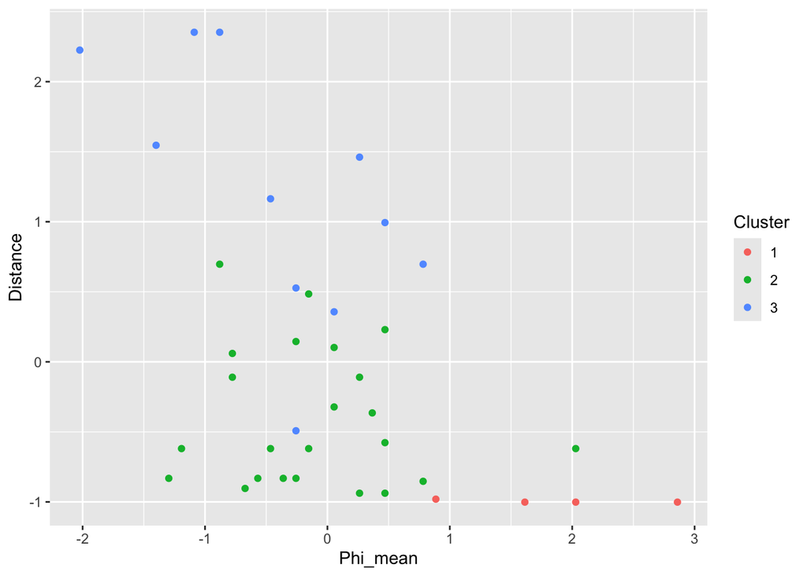

```r
ggplot(chem_dist, aes(x = Phi_mean, y = Distance, color = Cluster)) +
  geom_point()
```

In light of this new variable ‘Distance’ it looks like Cluster 1 is not relevant enough to be considered as a separate cluster, judging by distribution of Distoil itself and the scatter plot of Distoil and Redox. However, the relationship between Distoil and Phi_mean shows the potential need of the Cluster 1 being a separate cluster.

Overall, there is definitely a relation between Distoil and clustering pattern, so i would recommend to include Distoil into cluster analysis and see how it will affect on results.

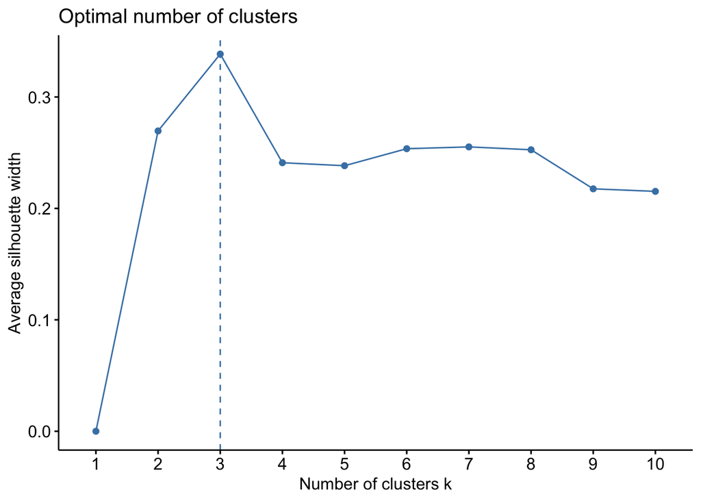

```r
#trying to see the effect of Distoil on clustering, out of curiousity
chem_dist1 <- chem_dist |>
  select(-Cluster)

chem_dist1 |>
  fviz_nbclust(kmeans, method = 'silhouette', k.max = 10)
```

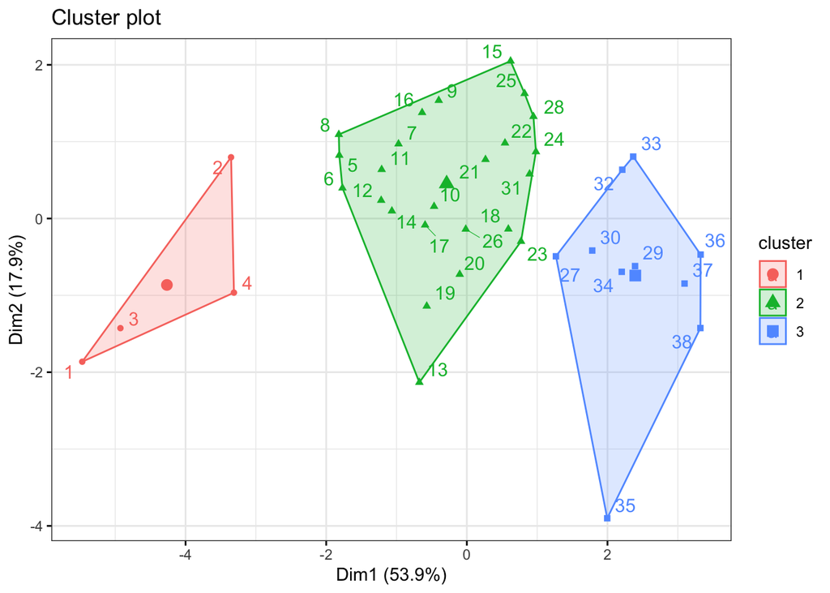

```r
set.seed(5555)
km_chem_dist <- kmeans(chem_dist1, centers = 3, nstart = 50)

km_chem_dist |>
  fviz_cluster(data = chem_dist1,
               repel = T,
               ggtheme = theme_bw())
```

We still got 3 clusters, but this time they are more prominent and the silhouette value is a bit higher, which implies that Distoil contributes to distinguish clusters on a certain level.

### 2: Association Rules

```r
books <- read.transactions('books.txt')

books |> head(n=10) |> DATAFRAME()
```

```
##                                                                                                                                        items
## 1                                                                                                  {book043,book065,book077,book143,book210}
## 2                                                                                  {book088,book194,book196,book225,book234,book235,book240}
## 3                                                                                          {book047,book126,book147,book163,book222,book224}
## 4                                                          {book013,book015,book126,book130,book148,book190,book213,book265,book272,book287}
## 5                                                                                  {book028,book077,book084,book112,book136,book188,book259}
## 6          {book013,book015,book052,book063,book079,book112,book126,book130,book151,book182,book213,book238,book265,book272,book279,book287}
## 7                                                                                                  {book043,book180,book225,book259,book272}
## 8                                          {book005,book027,book039,book043,book095,book106,book114,book136,book143,book276,book281,book297}
## 9                                          {book025,book079,book098,book114,book126,book130,book147,book183,book210,book257,book260,book276}
## 10 {book014,book025,book039,book040,book051,book077,book088,book117,book141,book152,book180,book205,book209,book225,book244,book272,book292}
```

```r
summary(books)
```

```
## transactions as itemMatrix in sparse format with
##  8000 rows (elements/itemsets/transactions) and
##  288 columns (items) and a density of 0.03649826
##
## most frequent items:
## book077 book129 book027 book059 book114 (Other)
##    1587    1436    1290    1213    1191   77375
##
## element (itemset/transaction) length distribution:
## sizes
##   1   2   3   4   5   6   7   8   9  10  11  12  13  14  15  16  17  18  19  20
##  34  54 137 241 412 539 643 737 710 739 724 627 536 472 365 299 242 170 101  81
##  21  22  23  24  25  26  27  28  29
##  56  32  19  15   8   3   1   1   2
##
##    Min. 1st Qu.  Median    Mean 3rd Qu.    Max.
##    1.00    7.00   10.00   10.51   13.00   29.00
##
## includes extended item information - examples:
##    labels
## 1 book001
## 2 book002
## 3 book003
```

#### Top 10 most popular books

```r
books |>
  itemFrequency() |>
  head(10)
```

```
##  book001  book002  book003  book005  book006  book007  book008  book009
## 0.026625 0.041250 0.050250 0.041750 0.023125 0.033750 0.017250 0.003875
##  book010  book011
## 0.060500 0.008125
```

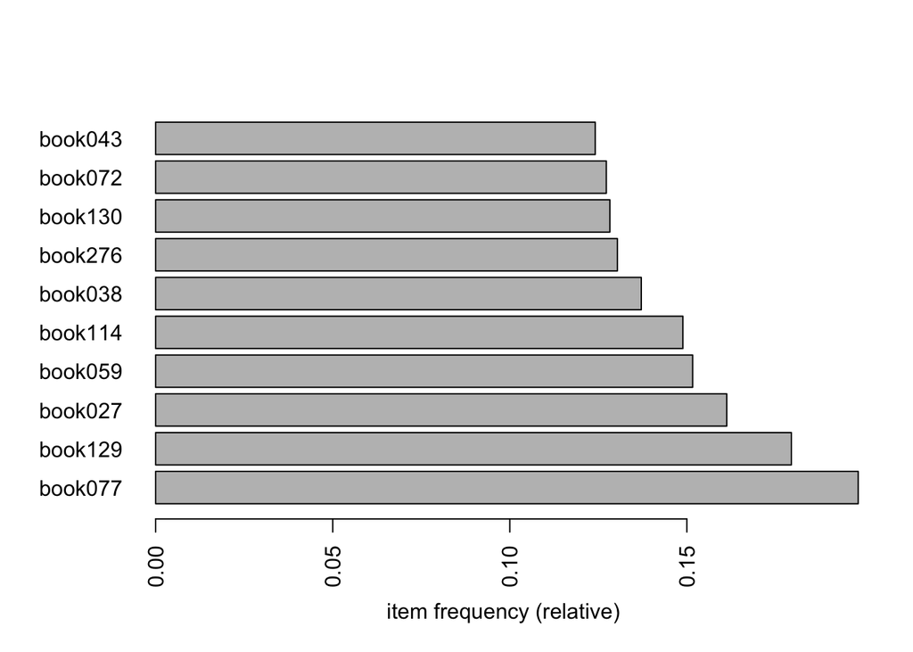

```r
books |>
  itemFrequencyPlot(support = 0.1,
                    topN = 10,
                    horiz = T)
```

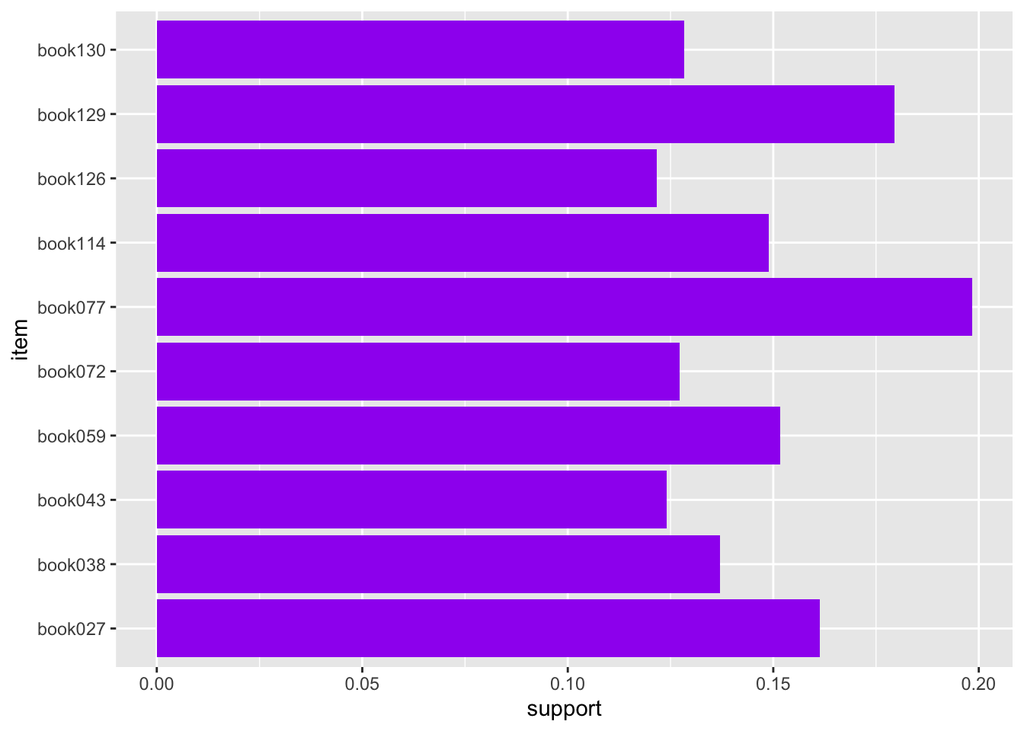

```r
#top 10 books in a bit more fancy way
books |>
  itemFrequency() |>
  enframe(name = "item", value = "support") |>
  filter(support > 0.1) |>
  head(10) |>
  ggplot() +
  geom_col(mapping = aes(y = item, x = support), fill = 'purple')
```

#### Rules with at least 50 members have borrowed the same set(s) of books (i.e. those with support 0.00625 with confidence = 0.5)

```r
book_rules <- books |>
  apriori(parameter = list(support = 0.00625, confidence = 0.5))
```

```
## Apriori
##
## Parameter specification:
##  confidence minval smax arem  aval originalSupport maxtime support minlen
##         0.5    0.1    1 none FALSE            TRUE       5 0.00625      1
##  maxlen target  ext
##      10  rules TRUE
##
## Algorithmic control:
##  filter tree heap memopt load sort verbose
##     0.1 TRUE TRUE  FALSE TRUE    2    TRUE
##
## Absolute minimum support count: 50
##
## set item appearances ...[0 item(s)] done [0.00s].
## set transactions ...[288 item(s), 8000 transaction(s)] done [0.00s].
## sorting and recoding items ... [244 item(s)] done [0.00s].
## creating transaction tree ... done [0.00s].
## checking subsets of size 1 2 3 4 5 6 done [0.01s].
## writing ... [724 rule(s)] done [0.00s].
## creating S4 object  ... done [0.00s].
```

```r
book_rules |>
  inspectDT()
```

|  | LHS | RHS | support | confidence | coverage | lift | count |
| --- | --- | --- | --- | --- | --- | --- | --- |
| [1] | {book057} | {book163} | 0.006375 | 0.6071428571428571 | 0.0105 | 5.012531328320802 | 51 |
| [2] | {book256} | {book194} | 0.006375 | 0.6455696202531646 | 0.009875 | 9.528702881965529 | 51 |
| [3] | {book256} | {book280} | 0.00675 | 0.6835443037974683 | 0.009875 | 6.668724915097252 | 54 |
| [4] | {book242} | {book115} | 0.007125 | 0.6627906976744186 | 0.01075 | 24.54780361757106 | 57 |
| [5] | {book242} | {book054} | 0.00675 | 0.627906976744186 | 0.01075 | 15.36163857478131 | 54 |
| [6] | {book242} | {book195} | 0.006625 | 0.6162790697674418 | 0.01075 | 11.4656571119524 | 53 |
| [7] | {book242} | {book025} | 0.007375 | 0.686046511627907 | 0.01075 | 9.853450795373888 | 59 |
| [8] | {book242} | {book043} | 0.00725 | 0.6744186046511628 | 0.01075 | 5.433382514812993 | 58 |
| [9] | {book242} | {book038} | 0.007375 | 0.686046511627907 | 0.01075 | 5.003073922537152 | 59 |
| [10] | {book242} | {book077} | 0.007125 | 0.6627906976744186 | 0.01075 | 3.34109992526487 | 57 |

[output cut: 714 more lines]

```r
book_rules |>
  head(50) |>
   plot(method = "graph", engine = "htmlwidget")
```

[interactive chart not shown]

724 rules matched our conditions

#### 5 rules with the highest support

```r
book_rules |>
  sort(by = "support") |>
  head(5) |>
  inspect()
```

```
##     lhs                   rhs       support  confidence coverage lift     count
## [1] {book041, book114} => {book027} 0.012500 0.5714286  0.021875 3.543743 100
## [2] {book027, book041} => {book114} 0.012500 0.6329114  0.019750 4.251294 100
## [3] {book111, book153} => {book072} 0.011625 0.5568862  0.020875 4.376316  93
## [4] {book072, book153} => {book111} 0.011625 0.5470588  0.021250 5.610860  93
## [5] {book012, book114} => {book027} 0.011000 0.5714286  0.019250 3.543743  88
```

The rule represent the relationship between items. For example, the most frequent rule is the one where when books 41 and 114 are borrowed, book 27 is also borrowed with them.

#### Rules for which lift is greater than 30

```r
book_rules |>
  subset(lift > 30) |>
  sort(by = "lift") |>
  head(50) |>
  inspect()
```

```
##      lhs                                     rhs       support  confidence
## [1]  {book115, book195}                   => {book242} 0.006250 0.7812500
## [2]  {book025, book038, book077}          => {book242} 0.006250 0.7352941
## [3]  {book025, book054}                   => {book242} 0.006250 0.6666667
## [4]  {book043, book115}                   => {book242} 0.006250 0.6578947
## [5]  {book025, book115}                   => {book242} 0.006500 0.6419753
## [6]  {book038, book115}                   => {book242} 0.006500 0.6341463
## [7]  {book111, book117, book180, book238} => {book214} 0.008125 0.9701493
## [8]  {book117, book180, book238}          => {book214} 0.008125 0.9558824
## [9]  {book111, book180, book238}          => {book214} 0.008125 0.9558824
## [10] {book012, book126, book135}          => {book134} 0.006250 0.9259259
## [11] {book111, book117, book180}          => {book214} 0.008125 0.9154930
## [12] {book025, book195}                   => {book242} 0.006375 0.5257732
## [13] {book111, book117, book238}          => {book214} 0.008125 0.8552632
## [14] {book025, book038}                   => {book242} 0.006750 0.5142857
```

[output cut: 59 more lines]

36 rules have a lift greater than 30

#### Practice scenario 1

Bob asks you for a book recommendation, saying he really enjoyed books 003 and 128. (i) Which books would you recommend to Bob? (ii) Which book would you recommend if you could only choose one?

```r
book_rules |>
  subset(lhs %ain% c("book003", "book128")) |>
  sort(by = "lift") |>
  head(10) |>
  inspect()
```

```
##      lhs                            rhs       support  confidence coverage
## [1]  {book003, book128, book279} => {book188} 0.006750 0.8709677  0.007750
## [2]  {book003, book128, book188} => {book279} 0.006750 0.9818182  0.006875
## [3]  {book003, book128, book194} => {book279} 0.006625 0.9464286  0.007000
## [4]  {book003, book128}          => {book188} 0.006875 0.5288462  0.013000
## [5]  {book003, book128, book129} => {book279} 0.006750 0.8307692  0.008125
## [6]  {book003, book128, book279} => {book194} 0.006625 0.8548387  0.007750
## [7]  {book003, book128, book129} => {book194} 0.006375 0.7846154  0.008125
## [8]  {book003, book128}          => {book279} 0.007750 0.5961538  0.013000
## [9]  {book003, book128}          => {book194} 0.007000 0.5384615  0.013000
## [10] {book003, book128, book194} => {book129} 0.006375 0.9107143  0.007000
##      lift      count
## [1]  24.534303 54
## [2]  15.677735 54
## [3]  15.112632 53
## [4]  14.897075 55
## [5]  13.265776 54
## [6]  12.617546 53
## [7]  11.581039 51
## [8]   9.519423 62
## [9]   7.947772 56
## [10]  5.073617 51
```

Considering Bob’s preferences, I’d recommend them books 188 and 279, since they are in the top 5 rules with the highest lifts and also co-occur in each others’ antecedents.

If we would recommend only one book, I’d choose 188, since it has the highest lift value, which means that itemset with books 3 and 128 in it increase the probability of choosing book 188 by almost 25 times.

#### Practice scenario 2

Bob remembers another book that he enjoyed: book 194. (i) Does this new information make you more or less confident that he’ll like your most recommended book from the previous question, any by how much? (ii) Should you stick with your previous recommendation or change it?

```r
book_rules |>
  subset(lhs %ain% c("book003", "book128", "book194")) |>
  sort(by = "lift") |>
  head(100) |>
  inspect()
```

```
##     lhs                            rhs       support  confidence coverage
## [1] {book003, book128, book194} => {book279} 0.006625 0.9464286  0.007
## [2] {book003, book128, book194} => {book129} 0.006375 0.9107143  0.007
##     lift      count
## [1] 15.112632 53
## [2]  5.073617 51
```

If we add book 194 into Bob’s preferences, it narrows our choice a lot, since we have only 2 rules with all 3 books in the antecedent itemset. Now we’re not that confident that Bob will enjoy book 188 the most, because there are no rules where all 4 books are present. However, the second book from our previous recommendation, book 279, appeared in a new search too. Even though the lift value is slightly lower (1512% vs 1568%, lower by around 56%), it still has a very high chance of being liked by Bob.

Anyway, the best choice of recommendation fro Bob is book 279, according to our new search.It appeared as a consequent for all 3 previously liked books, has a slightly higher confidence and significantly (3 times) higher lift. That indicates that occurences with books 3, 128 and 194 increase the occurrence of book 279 by 15 times.